# 一致性與情緒刺激之行為數據分析 (無母數檢定版)

Non-Parametric Analysis Report

組員劉鎮臺編寫報告

2025-12-14

**建立時間：** 2025-12-14 00:45:58

# 第一章 緒論 (無母數分析版)

本報告採用 **無母數統計方法 (Non-parametric Statistics)** 對行為數據進行驗證。相較於傳統 ANOVA，無母數方法（如 Wilcoxon Signed-Rank Test, Friedman Test）不需假設資料呈常態分佈，對於小樣本或反應時間這類常呈偏態分佈的資料更為穩健。

# 第二章 方法

## 2.0 行為資料快速視覺化

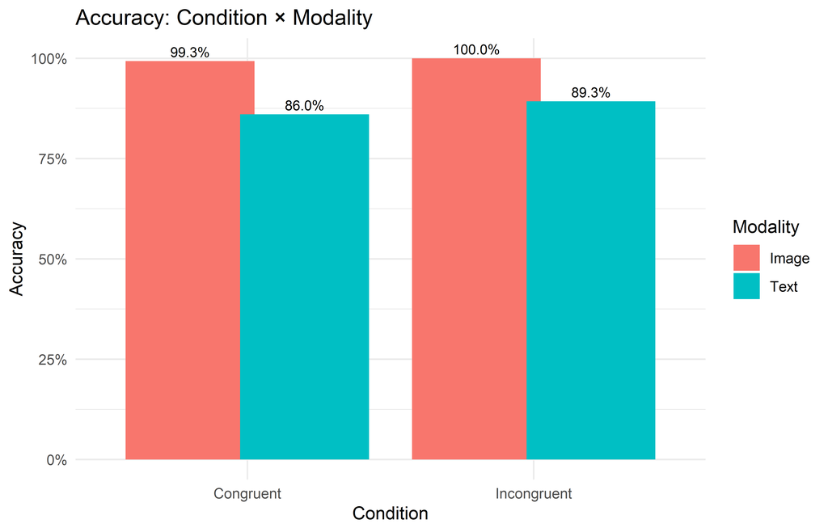

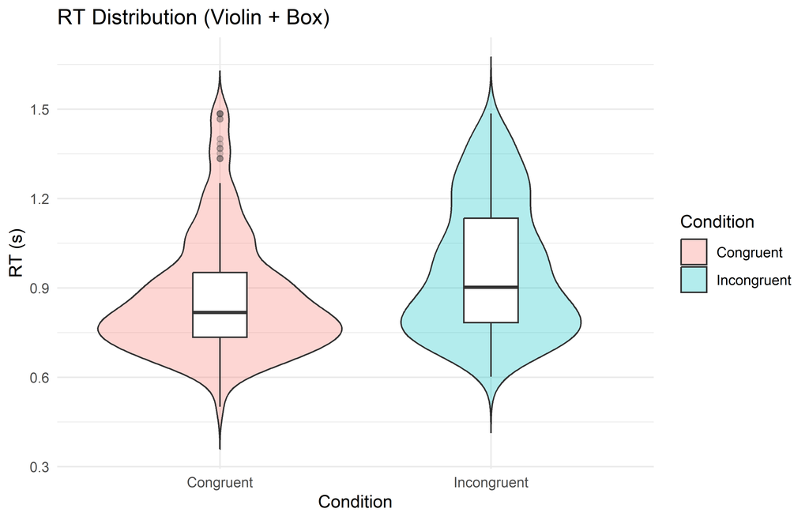

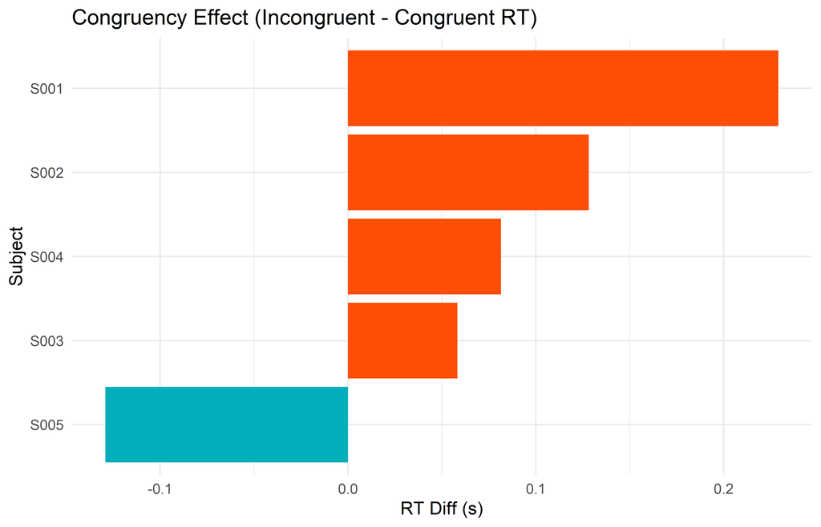

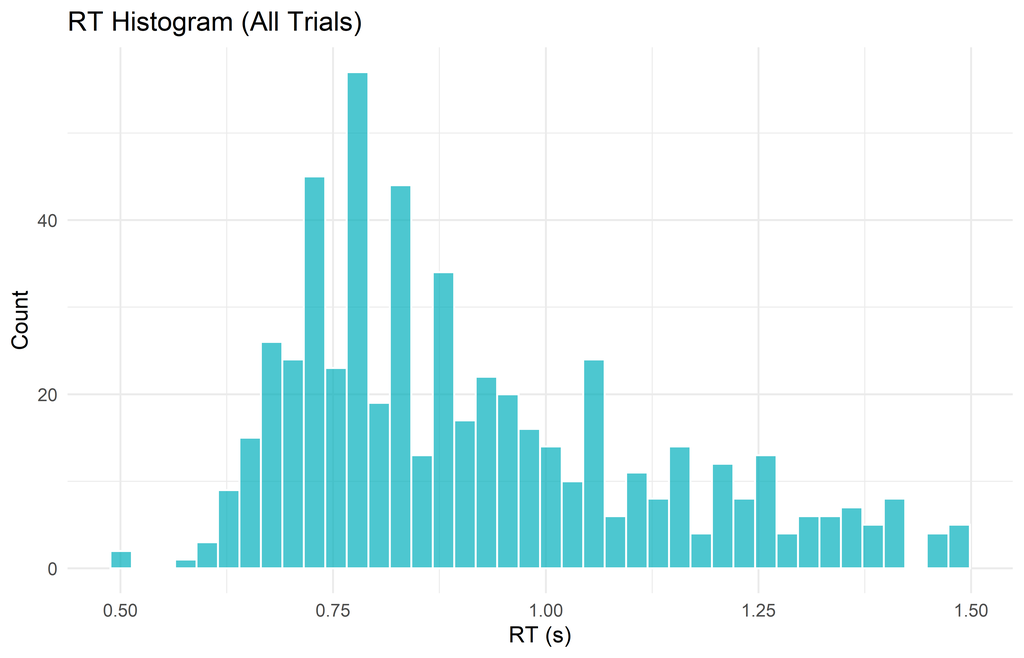

## 2.1 統計分析策略

# 第三章 結果

## 3.1 一致性主效應 (Wilcoxon Signed-Rank Test)

|  | estimate | .y. | group1 | group2 | n1.x | n2.x | statistic | p | conf.low | conf.high | method | alternative | p.signif | effsize | n1.y | n2.y | magnitude |
| --- | --- | --- | --- | --- | --- | --- | --- | --- | --- | --- | --- | --- | --- | --- | --- | --- | --- |
| 1 | -0.08153470188300826 | mean_rt | Congruent | Incongruent | 5 | 5 | 4 | 0.438 | -0.229127223776992 | 0.1291035406872191 | Wilcoxon | two.sided | ns | 0.422115882408869 | 5 | 5 | moderate |

### 一致性條件差異 (Boxplot + Jitter)

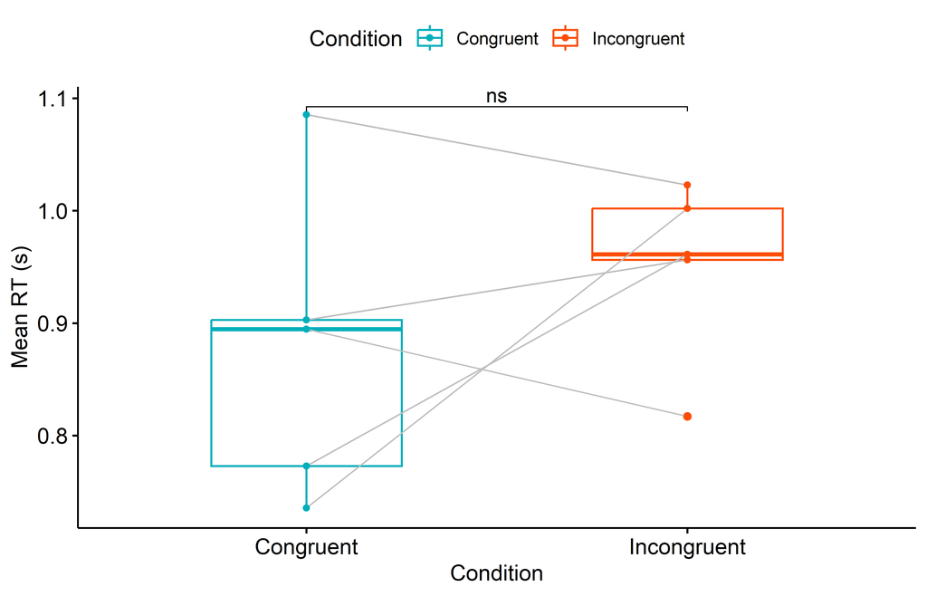

### 3.1b IAT 樣式 D 分數（標準化一致性效應）

|  | N | mean_D | sd_D | min_D | max_D |
| --- | --- | --- | --- | --- | --- |
| 1 | 5 | 0.2739279284350621 | 0.643497542529829 | -0.6180709886446646 | 0.9211516124931352 |

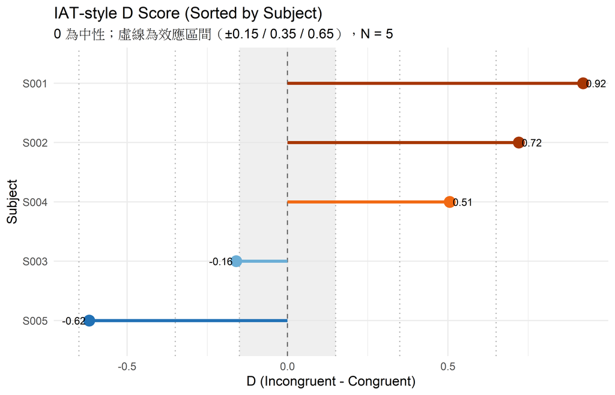

### 3.1c 分模態 IAT D 分數（Image vs Text）

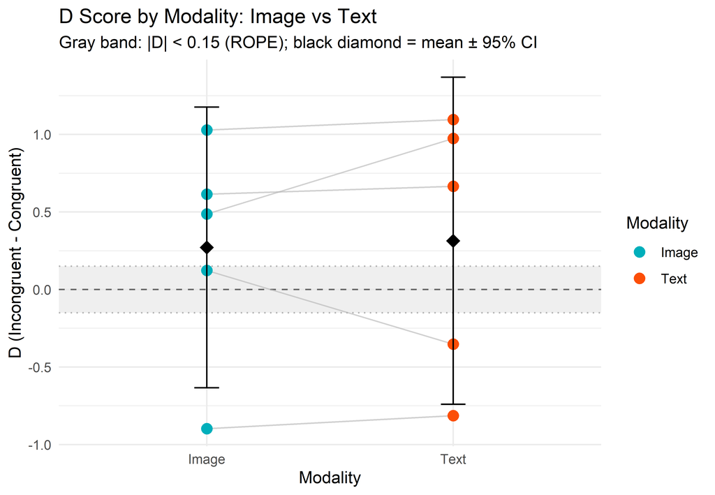

## 3.2 圖片實驗：無母數交互作用分析

### 3.2.1 整體差異 (Friedman Test)

|  | .y. | n | statistic | df | p | method |
| --- | --- | --- | --- | --- | --- | --- |
| 1 | mean_rt | 5 | 4.44 | 3 | 0.2177049960259654 | Friedman test |

### 3.2.2 交互作用檢驗 (比較一致性效應)

我們計算每個受試者在兩種圖片類型下的一致性效應 (Incongruent - Congruent)，並比較這兩個差值。

|  | .y. | group1 | group2 | n1.x | n2.x | statistic | p | p.signif | effsize | n1.y | n2.y | magnitude |
| --- | --- | --- | --- | --- | --- | --- | --- | --- | --- | --- | --- | --- |
| 1 | CE | Gay | Straight | 5 | 5 | 5 | 0.625 | ns | 0.3015113445777636 | 5 | 5 | moderate |

### 圖片類型對一致性效應 (CE) 的影響

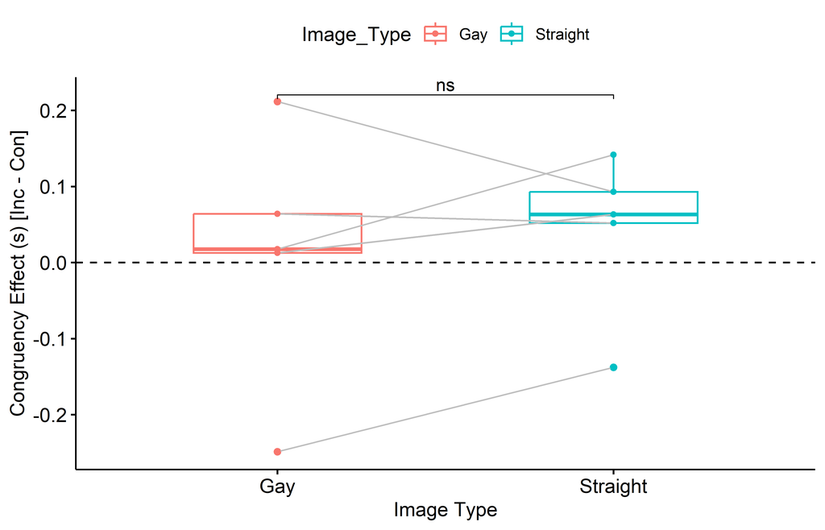

## 3.3 文字實驗：無母數交互作用分析

### 3.3.1 整體差異 (Friedman Test)

|  | .y. | n | statistic | df | p | method |
| --- | --- | --- | --- | --- | --- | --- |
| 1 | mean_rt | 4 | 26.65384615384615 | 11 | 0.005181571020044254 | Friedman test |

### 3.3.2 交互作用檢驗

**1. Valence × Condition (情緒效價是否調節一致性效應?)**

|  | .y. | group1 | group2 | n1.x | n2.x | statistic | p | p.signif | effsize | n1.y | n2.y | magnitude |
| --- | --- | --- | --- | --- | --- | --- | --- | --- | --- | --- | --- | --- |
| 1 | mean_CE | Negative | Positive | 5 | 5 | 3 | 0.312 | ns | 0.5427204202399745 | 5 | 5 | large |

**2. Arousal × Condition (喚醒度是否調節一致性效應?)**

```
## 資料不足以進行 Arousal 交互作用檢定。
```

**3. Valence × Arousal × Condition (三階交互作用)**

檢驗「不同喚醒度下，效價對一致性效應的調節是否不同」。 計算指標：`Interaction_Score = CE(Positive) - CE(Negative)`。 比較 `Interaction_Score` 在 High Arousal 與 Low Arousal 間的差異。

```
## 資料不足以進行三階交互作用檢定。
```

## 3.4 類別關聯 (卡方檢定)

|  | Correct | Error |
| --- | --- | --- |
| Congruent | 256 | 19 |
| Incongruent | 269 | 15 |

若樣本數不足 (期望值 < 5)，以下提供 Fisher’s Exact Test 結果：

|  | estimate | p.value | conf.low | conf.high | method | alternative |
| --- | --- | --- | --- | --- | --- | --- |
| 1 | 0.7517077962908583 | 0.4808128755497005 | 0.347329586525682 | 1.599018133802659 | Fisher's Exact Test for Count Data | two.sided |

# 第四章 匯出結果

```
## 無母數統計結果已匯出至：Master_Statistics_NonParametric.xlsx
```